# The Legacy of Civil War:Landmines, ERWs, and Their Effects on Cambodian Communities

Alvin Lim

29-Sep-2024

# Executive Summary

This report examines landmine and Explosive Remnants of War (ERW) incidents in Cambodia, focusing on their geographic distribution and the effectiveness of clearance efforts. Utilizing two datasets (landmine incidents and fear levels reported by clearing operators), the study highlights critical patterns affecting local safety and development.

Our key findings indicated landmine incidents are concentrated in Cambodia’s northwestern regions near the Thai border and around Phnom Penh, historically conflict-heavy zones. Despite significant efforts by organizations like CMAC and The HALO Trust, landmines continue to pose serious risks to the people, particularly in foraging areas, rice fields, and villages, which are vital to the livelihoods of many Cambodians.

Clearance activities have led to a reduction in landmine-related incidents since 2010, but residual risks remain. The probability of injury, amputation, or death upon triggering a landmine is still considerable, with anti-personnel and anti-vehicle mines being the most dangerous. Continued clearance efforts and targeted public education are essential to reducing these threats further.

In conclusion, while Cambodia has made progress in mitigating landmine risks, ongoing education, focused clearance in high-risk land-use areas, and resource optimization to protect communities and support economic development are still required.

# Introduction

With Cambodia rapid GDP growth since 1998 and high tourism rates (Wikipedia, n.d.), it is important for the land to be safe from any threats so that foreign direct investment (FDI) can proceed smoothly, and tourists feel safe to travel in the country. In this report, we will be investigating 2 datasets (landmine incidents <*mine.shp*> and fear level <*khm_blscontaminationp_gov_cmaa.shp*> by the mine clearing operators) in detail.  
In landmine incidents dataset, there are cases of landmine incidents, location of the incidents, type of mine and injury type (Injure, Amputation, Killed) recorded. As for fear level, there are landmine clearing operators records of mine clearing in each location with indication on the fear level, proximity of the landmine and land type.  
With the above datasets, we hope to understand how mine clearing was done by the operators, possible type of mines found in the land, type of land use in the location. Since the result of the landmine incident dataset still shows some landmine found in 2013, we can propose possible insight on the correlation of landmines type and landuse to related parties for further education on detection.

# Data Exploration

Before proceeding with the study, we evaluated both datasets and found the following variables which may be used for our studies.

*Both datasets:*

1. **geometry** : This variable contains the longitude and latitude of the villages.
2. **Province**, **District**, **Commune**, **Village** : Location of occurrences.
3. **SurveyDate**, **Incident_D** : Date of survey and landmine/ERW incident date.

*fear level dataset:*

4. **Fear_Level** : landmine/ERW fear level in the location.
5. **Proximity** : landmine/ERW proximity level.
6. **Operator**: landmine/ERW clearing operators.

*landmine/ERW incidents dataset:*

7. **INJURE**, **AMPUTATION**, **KILLED** : landmine/ERW injury type and number of victims.
8. **ERW_TYPE**, **MINE_TYPE** : Type of landmine/ERW (Anti-personal, fuse, etc)
9. **LANDUSE** : Location type of land (Foraging area, Rice fields, etc)

From the above variables, we will need to proceed with the following before being able to plot any graphs.

1. To convert the *shp* files into dataframe by using `read_sf` function.
2. Transform the geometry variables into lat-long coordinate system with `st_transform`. With the coordinates, we will be able to plot choropleth maps easily on the location.
3. In order to plot the Cambodia outline choropleth map, Province, District, Commune shapefiles were download from the Open Development Cambodia webpage. (Open Development Cambodia, 2023) function like `st_read` is required to convert the coordinates into dataframe (Cambodia_province, Cambodia_district, Cambodia_commune)
4. Merge **ERW_TYPE** and **MINE_TYPE** variables using `coalesce` function.
5. Convert **INJURE**, **AMPUTATION**, **KILLED** variables from wide format to long format.
6. Split the date of **SurveyDate**, **Incident_D** in Year, Month, Day variables for easy calculation and charting.
7. Removal of 1913 year record in fear level dataset because of outliner and limited data.

In addition to the above actions, there are also some replacements in variables’ records which will be covered in **Appendix 1**.

# History of Cambodia

Even since the start of the Cambodia Civil War from 1967 to 1975, landmines had been used by all Cambodian factions to prevent advancement of troops in the region. In 1979 to prevent more Cambodia refugees to enter Thailand, Thai soldiers were stationed to shoot anyone who cross the no men’s land border with landmine deployed. (Wikipedia, n.d.) Other than landmines, Explosive remnants of war (ERW) also remained in Cambodia grounds due to long history of wars which took place in the country.

### K5 Plan

After the Cambodian-Vietnamese War from 1978 to 1979, Khmer Rouge fled and regroup behind the Thai-Cambodian border. In order to their resurgence into Cambodia land, People’s Republic of Kampuchea (PRK) triggered the K5 plan which included clearing the land to leave a foraging area along the Thailand border so that it can be watched and mined, (Wikipedia, n.d.) This plan did not deter Khmer Rouge from entering the country and created several social issues even until today.

### Evidence of the landmine/ERW

These landmines/ERW that are used during the Civil War and post-Khmer Rouge regime can still be seen in the below figure even in 2009 (30 years after the Civil War). From the figure, we observed that the major fear level is located in the north-western near the Thailand border which we can infer that those landmines/ERW have remained after the wars. Till 2013, there are still high fear level landmines detected in the regions.

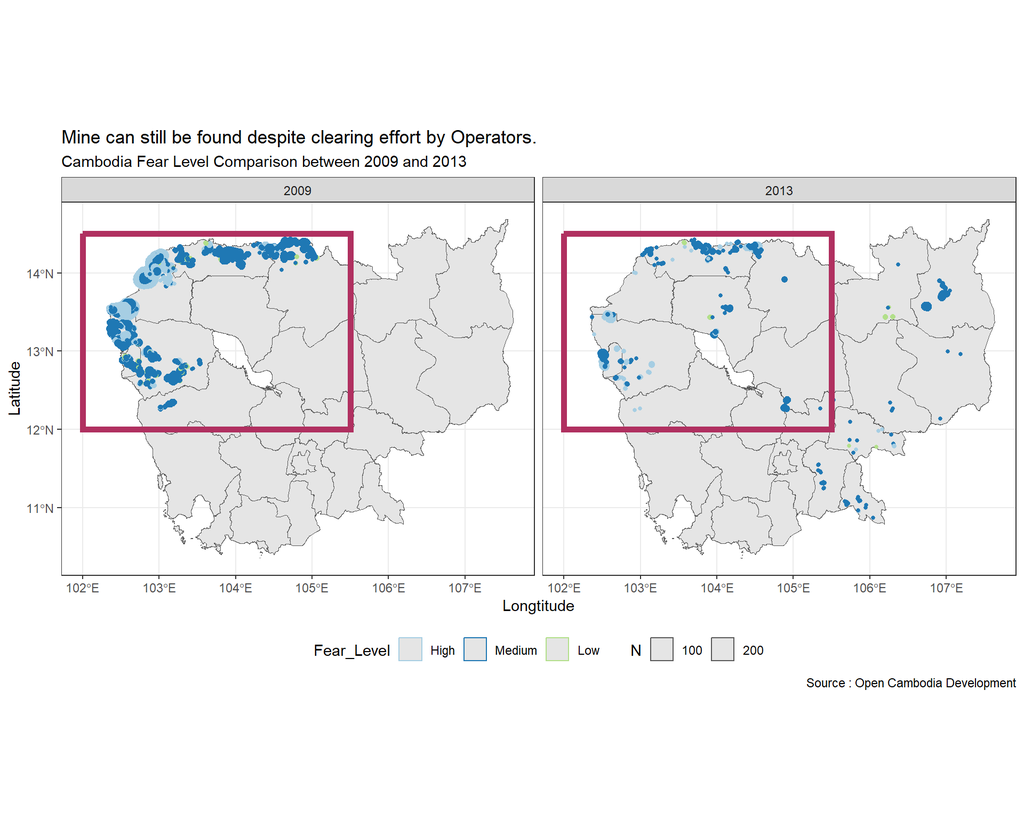

In the landmine incident datasets, we identify 2 major areas highlighted in the below figure in red and blue. Similar to fear level result above, most of the incidents occurred in the northwestern region near the Thailand border. There is also another area around Phnom Penh where several wars were fought. For example, Khmer Rouge took control of the province in 1975 and invasion of Vietnam from 1978 to 1979 into Cambodia and form rival government (PRK). We can estimate ERW might have remained on ground due to several wars and landmines were also deployed around the province during the wars. From the below figure, we can observe that despite operators’ strong effort, there are still landmine/ERW incidents that occurred in 2013.

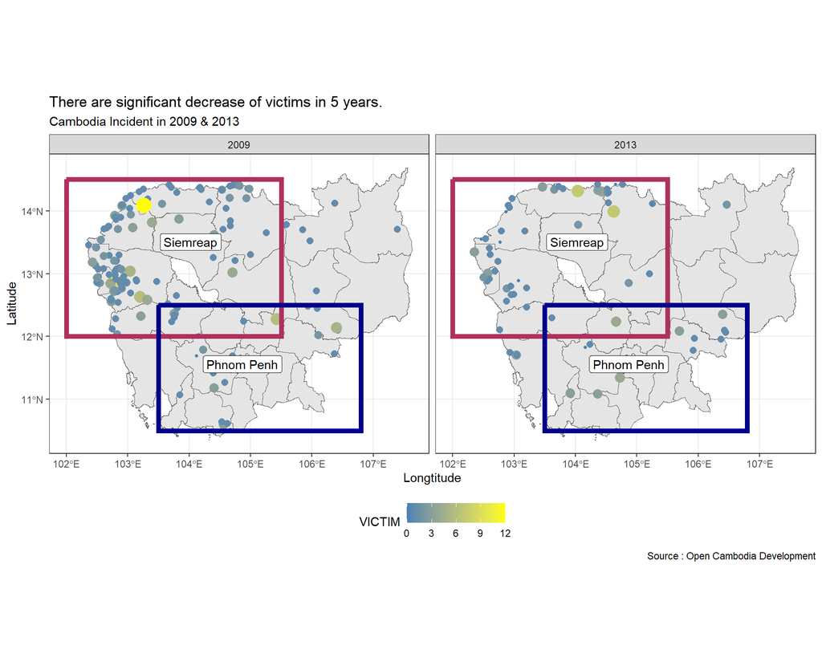

# Cambodia Fear Level from 2009 to 2012

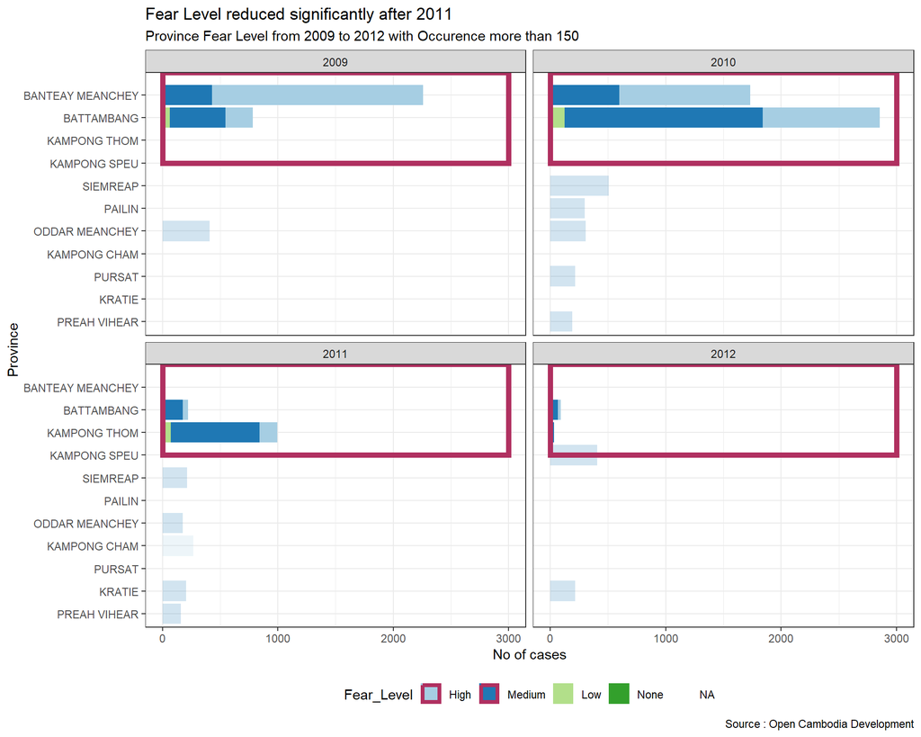

In the top 3 Province found with landmines, we observed that fear level in the provinces were generally Medium and High with 2 type of landmine proximity, Near and Very Near. The ratio of the Near proximity is generally higher than Very Near in both categories. This indicated that the damage of the landmines/ERW to the people who triggered it was still lethal.

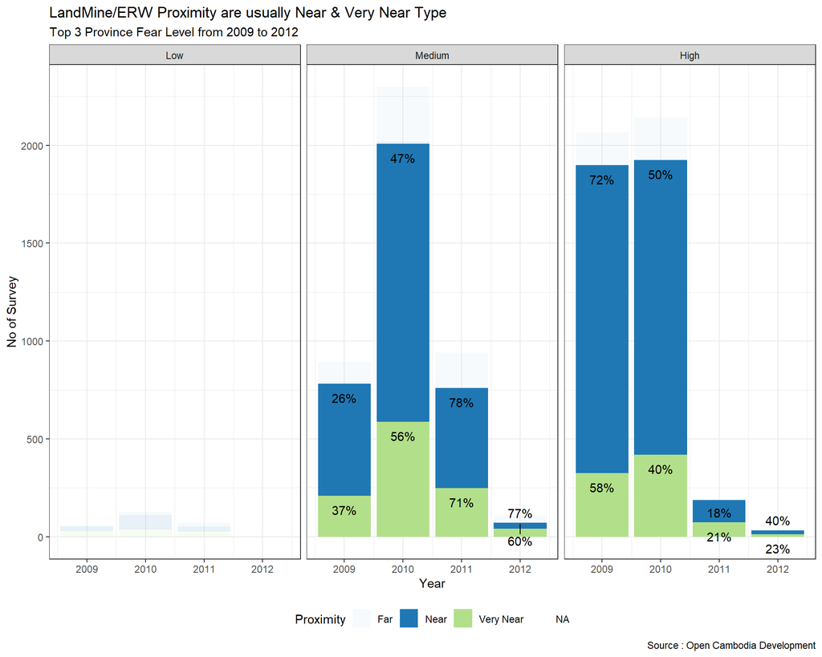

## Major Landmine Clearing Operators

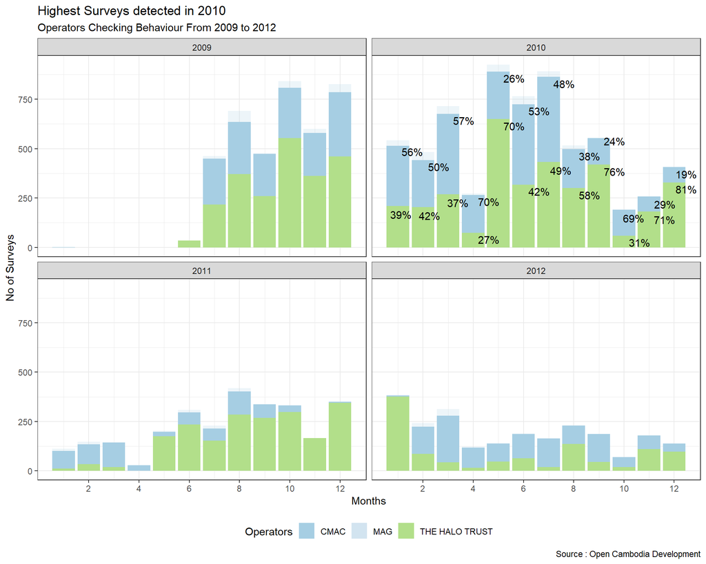

### Cambodian Mine Action Centre (CMAC)

CMAC, established in 1992, was one of the main organizations helping to make Cambodia land safe for residents in Cambodia and development. In the below figure, we observed that the main activities for CMAC was found in the northwestern of Cambodia and surveys were mostly finished in 2011. The focus was then shifted to another border of Cambodia as shown in 2012. One of the possible reasons for the shift in focus might be due to historical records of landmine/ERW incidents in 2005 where several injuries were found around Phnom Penh.

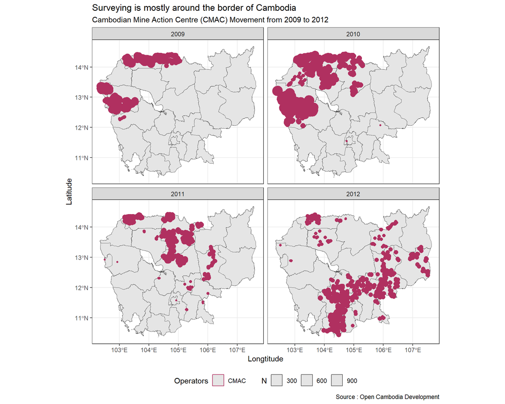

### The HALO Trust (HALO)

The HALO Trust is a global humanitarian non-government organisation which also helps to clear landmines left behind by wars and other conflicts. They also started their activities near the Thai border from Koh Kong to Preah Vihear and progressively move through the country based on locals’ request calls. (The Halo Trust, n.d.) In the below figure, their activities were shifted through the country in the central region where the land can be used for the people livelihood after clearance.

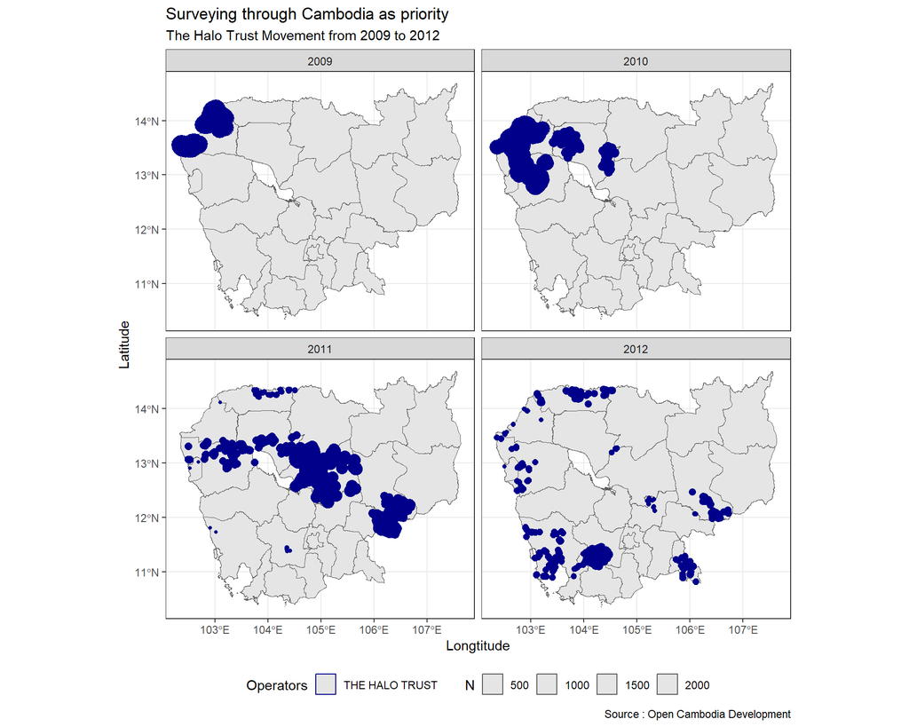

# Landmine/ERW incidents trend from 2005 to 2013

In the below figure, we observed that there was a significant decrease in the landmine/ERW incidents after the Operators’ clearance activities, but the ratio of the landmine/ERW effects is still similar between 2013 and 2005. This mean that there will still be 19% chance of amputation, 61% chance of injury or even 20% chance of get killed when triggered any landmine/ERW in 2013.

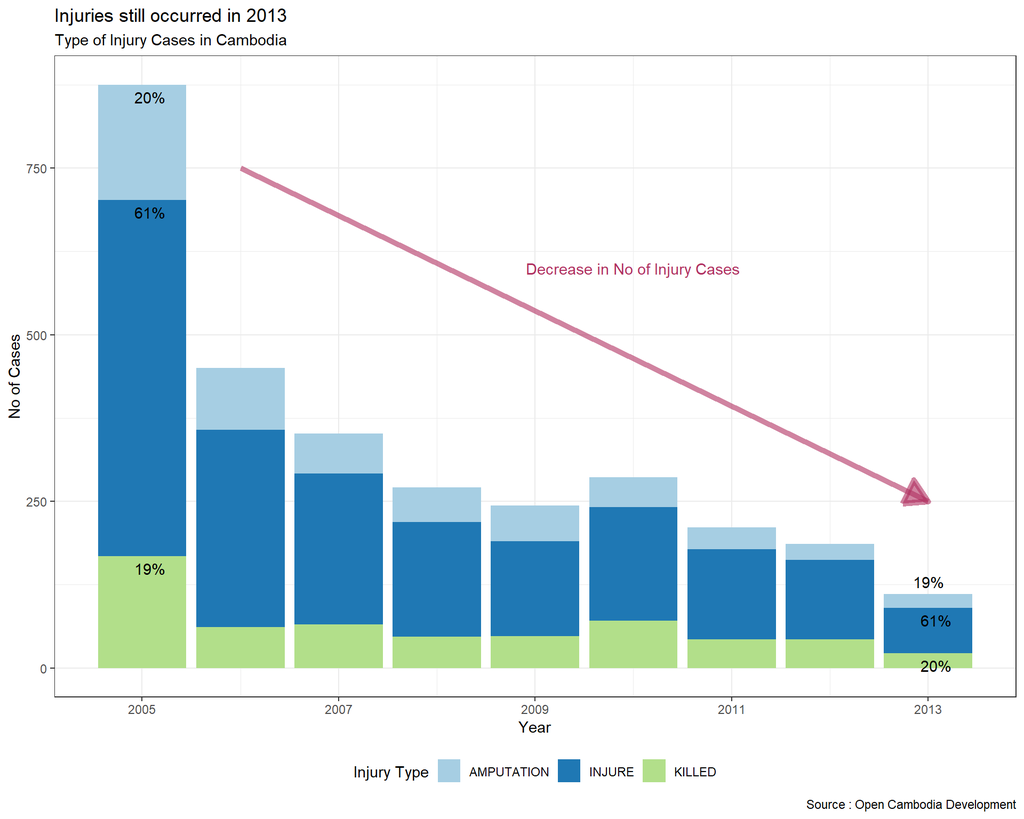

### Popular Landmine/ERW area in Cambodia

In order to effectively educate the people in Cambodia on possible danger area, we summarize all the landuse area where incidents occurred. In the below figure, there are 10 types of landmine/ERW found in Cambodia and top 3 most popular landuse types were Foraging area, Village or urban/built-up area, Rice Field. From the results, we can estimate that landmines were usually deployed at Foraging area and Rice field because of better line of sight of any enemies especially when explosion occurred, Fuse and Mortar rounds are found in Village or urban/built up area because of the ongoing prolong wars in the country.  
These locations were actually dangerous to the people of Cambodia because their livelihood depend on agriculture mainly. They might be exposed to high risk when managing the farms (Rice field) and have difficulty finding new areas for farming (Foraging area).

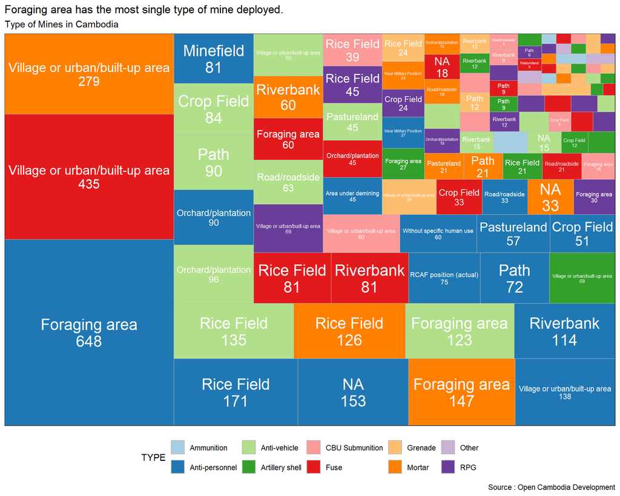

### Top 3 Landuse Study

In the below figure, anti-personal mines were used more in the foraging area, rice field than in the village or urban/buildup area. One of the possible reasons might be it is easier to deploy in lesser people’s environment and injuries on allies could be kept minimum. Another reason might be to reduce the watchout points where intruders who stepped on the landmine would be alarmed with explosion and easily spotted. Due to the open field condition of rice field where vehicles can advance easily, anti-vehicles mine could also be found to prevent quick advancement of troops. Lastly in order to prevent troops advancement and reduce troops quantity, area damage weapon mortars, fuses were usually used in the war and ERW of the shell and fuses might remain after the war end. All of these are dangerous when people touch or trigger it.

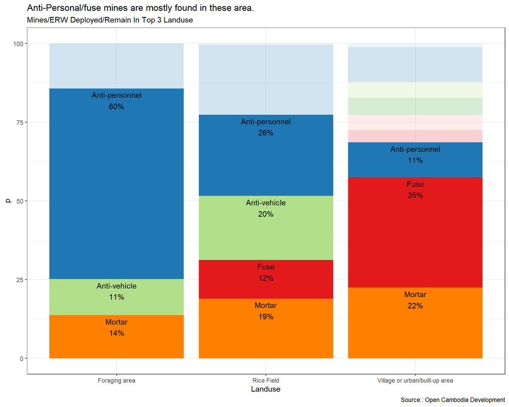

### Injuries caused by major types of landmines/ERW

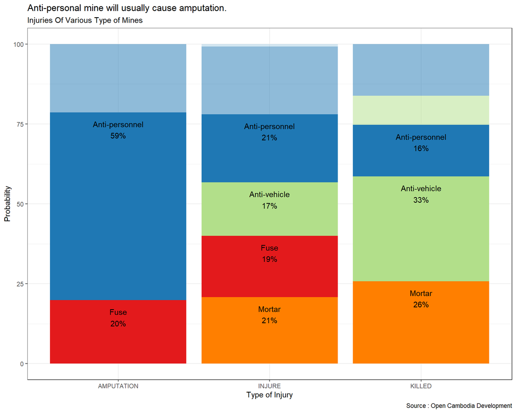

### Type of landuse found in most Landmine/ERW Province (2005)

Since 2005 is one of the largest amounts of landmine/ERW incidents, we evaluate the top 3 province incidents during that year as a benchmark. From the below figure, we observed that the incidents occurred mostly at the Foraging area (32% to 50%), Village or Urban/built-up area (14% to 50%) and Rice field (9%). This mean that it is risky for people of Cambodia to search for food in the Foraging area, managed their rice field and wandered around in the village.

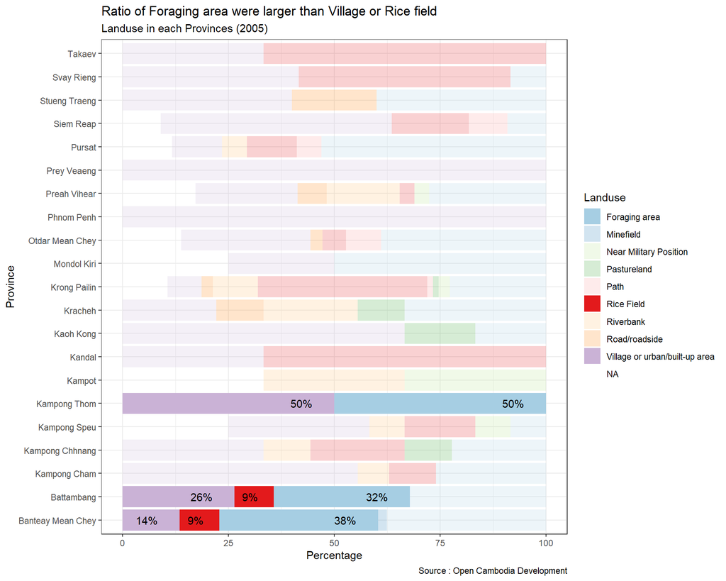

### Sign of reduction in Landmine/ERW incidents

As Agricultural activities are the main source of income in Cambodia, it is important to keep the land safe from any landmine/ERW. Luckily through the years of mine clearing by the Operators, we do see a great reduction in incidents in the below figure. However, we should not feel complacent about the result because there were still chance for the people of Cambodia to encounter landmine/ERW during their daily activities like farming or clearing the foraging area for agricultural activities or other development.

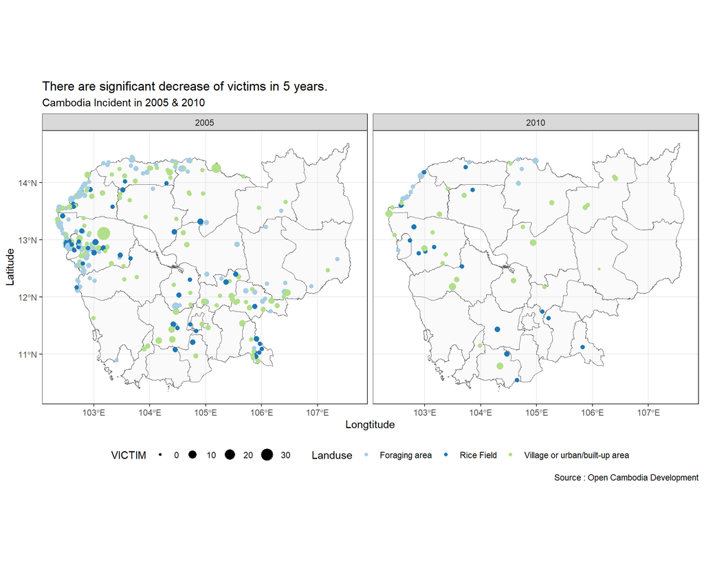

### Landmine/ERW incidents still occured after 24 years

The below figure showed landmine/ERW incidents still occurred in the 3 major landuse type (Foraging area, Rice field, Village/urban built-up area). This means that the country is still at risk of landmine/ERW incidents. With the inflow of foreign direct investment (FDI) in construction and real estate, rapid development of land will take place. Therefore, it is important for workers or people of Cambodia to learn how to live with the risk and understand the proper procedure on clearing one when they encountered it.

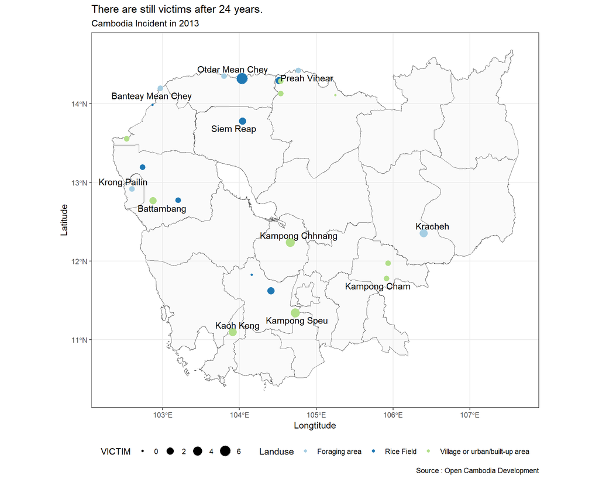

# Conclusion

The study reveals that while achieving a completely mine-free Cambodia is unlikely, several steps can be taken to mitigate the risks posed by landmines and ERW. First, continuous education of local communities is essential to help people recognize and respond to these threats, especially in high-risk areas. Public awareness campaigns and training should be tailored to different age groups to ensure maximum effectiveness.

Operators should also prioritize clearance efforts in the top three land-use areas, particularly foraging areas, rice fields, and villages so as to safeguard livelihoods and support agricultural activities. Further improvement in landmine risk reduction can be achieved by incorporating demographic data into training programs, enabling more targeted safety education.

Additionally, monitoring landmine incidents beyond 2013 can also help refine clearance strategies, allowing operators to focus resources more effectively and adjust their efforts based on emerging trends. This data-driven approach will optimize resource allocation and enhance the safety of communities across Cambodia.

### RMarkdown File Attached Below

# References

Open Development Cambodia (2023) *Basic map of Cambodia (2014)* Retrieved 4th December 2023 from

https://data.opendevelopmentcambodia.net/dataset/administrative-boundaries-of-Cambodia-2014

The Halo Trust (n.d.). *Cambodia* Retrieved from https://www.halotrust.org/where-we-work/south-asia/cambodia/

Wikipedia (n.d.). *Economy of Cambodia* Retrieved 17th September 2024 from

https://en.wikipedia.org/wiki/Economy_of_Cambodia

Wikipedia (n.d.). *K5 Plan* Retrieved 29th July 2024 from

https://en.wikipedia.org/wiki/K5_Plan

Wikipedia (n.d.). *Land mines in Cambodia* Retrieved 14th February 2024 from

https://en.wikipedia.org/wiki/Land_mines_in_Cambodia

# Appendix 1 : Data Cleaning Issues

In order to preserve the coordinates in the datasets, we will need to import the shapefile into R with `read_sf` command below.

```r
# Load datasets with geometry in environment
cambodia_fear.df <- read_sf(dsn = "./mine/khm_blscontaminationp_gov_cmaa.shp")
cambodia_mine.df <- read_sf(dsn = "./fear/mine.shp")
str(cambodia_mine.df) # Check data frame
str(cambodia_fear.df) # Check data Frame
```

st_transform` was used to obtain the longitude and latitude from the geometry variables.

```r
# Transform the geometry into lat-long coordinate system
cambodia_fear.df$geometry <-  st_transform(cambodia_fear.df$geometry,crs=4326)
cambodia_mine.df$geometry <- st_transform(cambodia_mine.df$geometry,crs=4326)
```

To draw the country outline as Choropleth map, we need to `st_read` the shapefiles of province, district, commune obtained from Open Development Cambodia (2023) webpage. With the coordinates, we will be able to create the Cambodia base map with province, district, commune details.

```r
# Read Cambodia Province, District, Commune Map
cambodia_province <- st_read("basemap_province.gpkg")
cambodia_district <- st_read("basemap_district.gpkg")
cambodia_commune <- st_read("basemap_commune.gpkg")
```

Since ERW_TYPE and MINE_TYPE belong to the same categories, we merge them into one variable as TYPE variable. It will be easier to plot any charts to understand which type of landmine/ERW injured the people of Cambodia.

```r
# Merge ERW & Mine Type in one column
cambodia_mine.dfe <- cambodia_mine.df %>%
  mutate(TYPE = coalesce(ERW_TYPE,MINE_TYPE)) %>%
  select(-c(ERW_TYPE, MINE_TYPE))
```

Long format is usually preferred during plotting charts. Therefore, we have to use `pivot_longer` on mine dataset to combine different type of injury (AMPUTATION, INJURIED, KILLED) into one variable. In this way, it will be easier to plot any column chart.

```r
# Convert Wide Format to Long Format
cambodia_mine.dfl <- cambodia_mine.dfe %>%
  pivot_longer(cols=13:15, names_to="INJURY_TYPE", values_to="CASES")
```

For easier time series plot, we will split the date variables into 3 variables (Year, Month, Day). In this way, we could easily call the required date variables for plotting any time series plot. On the safe side, we will define these variables as Integer to prevent any decimal points from occuring.

```r
# Split Dates into Year, Month, Day
cambodia_mine.dfle <- cambodia_mine.dfl %>%
    mutate(Incident_D = as.Date(Incident_D), year=year(Incident_D),
           month=month(Incident_D), date = day(Incident_D))
cambodia_fear.dfe <- cambodia_fear.df %>%
    mutate(SurveyDate = as.Date(SurveyDate), year=year(SurveyDate),
           month=month(SurveyDate), date = day(SurveyDate))

# Set year and month as Integer
cambodia_mine.dfle$year <- as.integer(cambodia_mine.dfle$year)
cambodia_mine.dfle$month <- as.integer(cambodia_mine.dfle$month)
cambodia_fear.dfe$year <- as.integer(cambodia_fear.dfe$year)
cambodia_fear.dfe$month <- as.integer(cambodia_fear.dfe$month)
```

Once all the datasets are arranged properly, we will need to review the class type of each variable and search for any missing or wrong data in the records of the variables. The commands below were used to check the class type and some of the records for both datasets. Sometimes, weird records might be short during `str()` check.

```r
# Verify class for each variables.
str(cambodia_mine.dfle)
str(cambodia_fear.dfe)
head(cambodia_mine.dfle)
head(cambodia_fear.dfe)
```

During data checking, we found “(blank)”, “Unknown” records in some of the variables and will perform `gsub()` to replace it to “NA” for easier identification. We also remove the row which year is 1913 because there are insufficient similar records in the dataset and it will be treated as outliner during any plotting of the charts. As country knowledge is required for replacing any NA records correctly and the NA records are small sample size, we will not take any actions in this study.

```r
# Replace "(blank)" with Null in variables.
cambodia_fear.dfe$Fear_Level <-
  gsub(pattern = "(blank)", replacement = NA,
       x=cambodia_fear.dfe$Fear_Level, fixed = TRUE)
cambodia_fear.dfe$Proximity <-
  gsub(pattern = "(blank)", replacement = NA,
       x=cambodia_fear.dfe$Proximity, fixed = TRUE)
cambodia_mine.dfle$Landuse <-
  gsub(pattern = "Unknown", replacement = NA,
       x=cambodia_mine.dfle$Landuse, fixed = TRUE)
cambodia_mine.dfle$TYPE <-
  gsub(pattern = "Unknown", replacement = NA,
       x=cambodia_mine.dfle$TYPE, fixed = TRUE)
# Drop row which year is 1913
cambodia_fear.dfe <- cambodia_fear.dfe[-which(cambodia_fear.dfe$year=="1913"),]
```

In order to plot any column chart with percentage, we will need to tabulate the results in a newly constructed dataframe before any chart can be plotted. In the below code, we perform 2 group_by so that we can summarize by year and Injury_Type with no duplicate records. After subtotals were obtained for each Injury_type, we will be able to calculate the percentage against the year total.

```r
# Construct Grouped Data by year, Injury Type and calculate the percentage.
cambodia_mine.consolidate <- cambodia_mine.dfle %>%
    group_by(year, INJURY_TYPE) %>%
    summarize(N = n(), subtotal = sum(CASES), .groups = 'drop') %>%
    ungroup() %>%
    group_by(INJURY_TYPE) %>%
    mutate(Total_injury_type = sum(subtotal)) %>%   # Total by INJURY_TYPE
    ungroup() %>%
    group_by(year) %>%
    mutate(Total_year = sum(subtotal),pct =round((subtotal/Total_year)*100,2))
```